# Financial Contributions to Presidential Candidates

Gareth Hunt

30 March 2016

## Introduction

This report takes a look at the Financial Contributions made to Presenditial Campaigns in the state of New York for 2016. The primary dataset was downloaded from [datasource](http://fec.gov/disclosurep/PDownload.do), however I also created a list of cities in New York along with the latitude and longitude. This data was extracted from [city_datasource](http://www.geonames.org)

## Data Structure

| Variable | Name | Meaning / Use |
| --- | --- | --- |
| cmte_id | Committee ID | A 9-character alpha-numeric code assigned to a committee by the Federal Election Commission. |
| cand_id | Candidate ID | A 9-character alpha-numeric code assigned to a candidate by the Federal Election Commission. |
| cand_nm | Candidate Name | Recorded name of the candidate |
| contbr_nm | Contributor Name | Reported name of the contributor. |
| contbr_city | Contributor City | Reported city of the contributor |
| contbr_state | Contributor State | Reported state of the contributor |
| contbr_zip | Contributor Zip Code | Reported zip code of the contributor |
| contbr_employer | Contributor Employer | Reported employer of the contributor |
| contbr_occupation | Contributor Occupation | Reported occupation of the contributor |
| contb_receipt_amt | Contribution Receipt Amount | Reported contribution amount |
| contb_receipt_dt | Contribution Receipt Date | Reported contribution date |
| receipt_desc | Receipt Description | Additional information reported by the committee about a specific contribution |
| memo_cd | Memo Code | ‘X’ indicates the committee has provided additional text to describe a specific |
| memo_text | Memo Text | Additional information reported by the committee about a specific contribution |
| form_tp | Form Type | Indicates what schedule and line number the reporting committee reported a specific transaction |
| file_num | File Number | A unique number assigned to a report and all its associated transactions |
| tran_id | Transaction ID | A unique identifier for each transaction |
| election_tp | Election Type | This code indicates the election for which the contribution was made. EYYYY (election plus election year) |

To help with the analysis I have added some additional fields to the dataset

| Variable | Meaning / Use |
| --- | --- |
| month | used for grouping data by month |
| week | used for grouping data by week |
| year | used for grouping data by year |
| latitude | stores the latitude based on the reported contribution city |
| longitude | stores the longitude based on the reported contribution city |
| employment_status | stores the employment status of each contributor based on the listed employer |

**Note:** In order to get the latitude and longitude to match the city, I needed to match the city from the cities dataframe to the cities in the financial dataframe. However initially there was an issue with some of the names not matching up. I was able to use a Python script from a previous project to create matches and fix differences in the spelling of cities.

Once I had added the additional fields, I was able to start analysing the data and to help with this I created a couple of grouping / summaries of the data:

- financial.group_by_city - used to plot and analyse the number and value of contributions by city
- financial.group_by_candidate - used to plot and analyse the contributions made to different candidates
- financial.group_by_employment - used to plot and analyse contributions made based on the status of employment

## Univariate Analysis

### What are the main feature(s) of interest in your dataset?

The main features of this dataset include the candidate and the value of the contributions that they received. The data below shows the break down of the contributions.

```
## Total Value of Contributions:  33973374
## Total Number of Contributions:   77438
## Average Value of Contribution: 438.7171
## Maximum Contribution Value:       10800
## Minimum Contribution Value:        0.1
## Number of Candidates:                22
## Number of Contributors:           22384
```

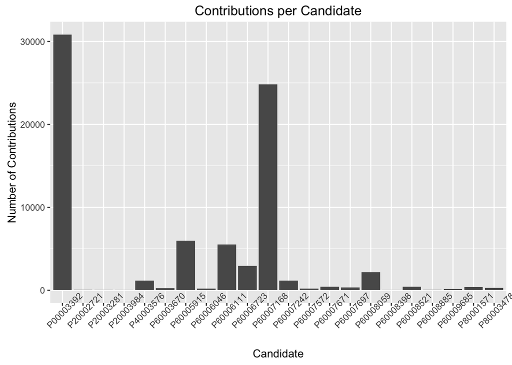

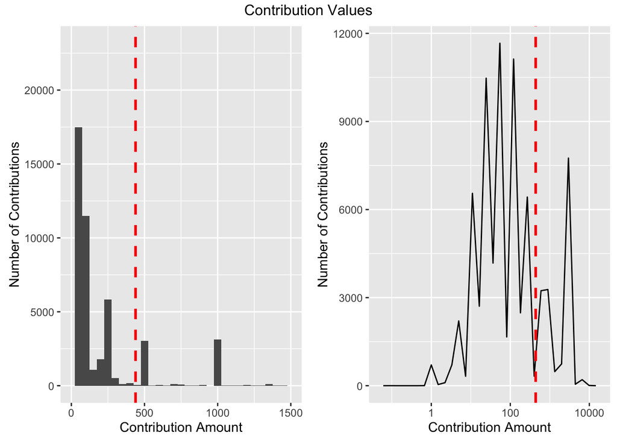

The first plot in the group above shows that the data is right skewed with the majority of the contributions been less than or equal to $500. So in order to see the spread of data better I performed a log transform on the transaction amount, which can be seen in the second plot of the group.

### What other features in the dataset do you think will help support your investigation into your feature(s) of interest?

Other features in the dataset that would be useful to investigate are:

- Contributor Occupation / Employer - to see if there are any trends based on the type of occupation or employer, in particular to compare employed vs unemployed.
- Location of contributors - to see if there are particular areas of New York that prefer different candidates
- Receipt Date of the Contribution - to see if there are certain times (weeks or months) of the campaign that would encourage more people to contribute

#### Contributor Occupation / Employer

When first looking at the grouping of the employer and occupation of the employer, I could see that there were:

```
## Employers:  9354
## Occupations: 4383
```

This posed an issue with been able to determine if there were any distinct patterns, as some of these could have been similar occupations with different titles or the same employers with different names or recorded differently. So in order to determine if there were any patterns I created an additional variable in the dataset for employment status, based on the listed employer.

```
## Source: local data frame [5 x 5]
##
##   employment_status contribution_count contribution_value avg_contribution
##               (chr)              (int)              (dbl)            (dbl)
## 1          EMPLOYED              42666         22473880.3         526.7398
## 2     SELF EMPLOYED              10768          4650264.1         431.8596
## 3           RETIRED               8984          1952882.1         217.3733
## 4      NOT EMPLOYED               7654           876561.9         114.5234
## 5           UNKNOWN               7366          4019785.3         545.7216
## Variables not shown: max_contribution (dbl)
```

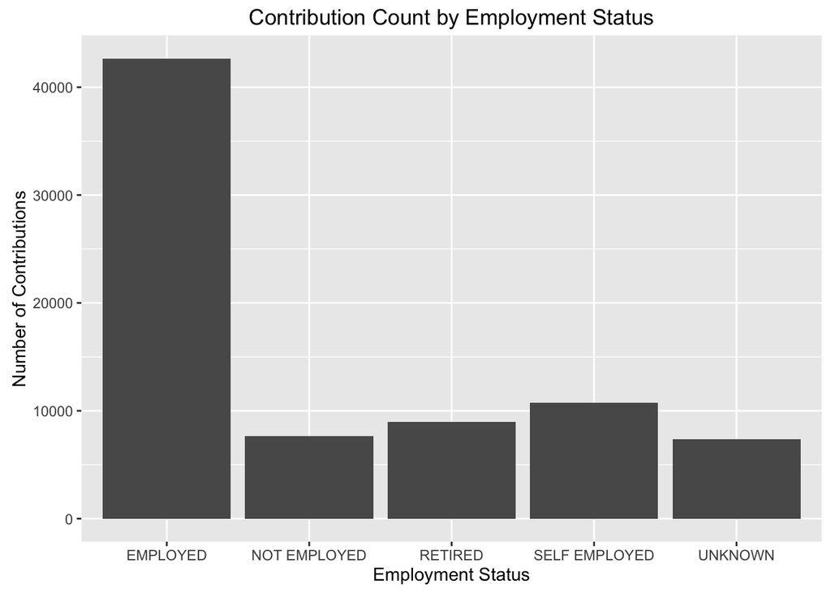

From this plot we are able to see that the bulk of the contributions came from contributors that are employed at the time of the contribution.

#### Location of contributors

The plot below shows us that the location of contributions were generally spread out across the state of New York, with a couple of districts (Capital District and CentralNew York), that had a larger number of contributions. This is probably reflective of the population spread across the state of New York and where businesses are generally located.

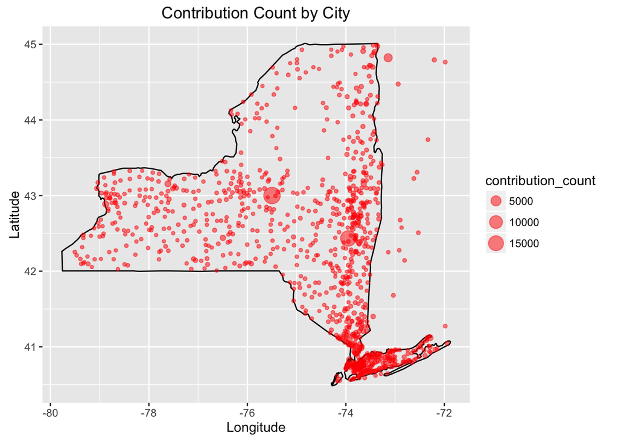

#### Contributions over time (Receipt Date of the Contribution)

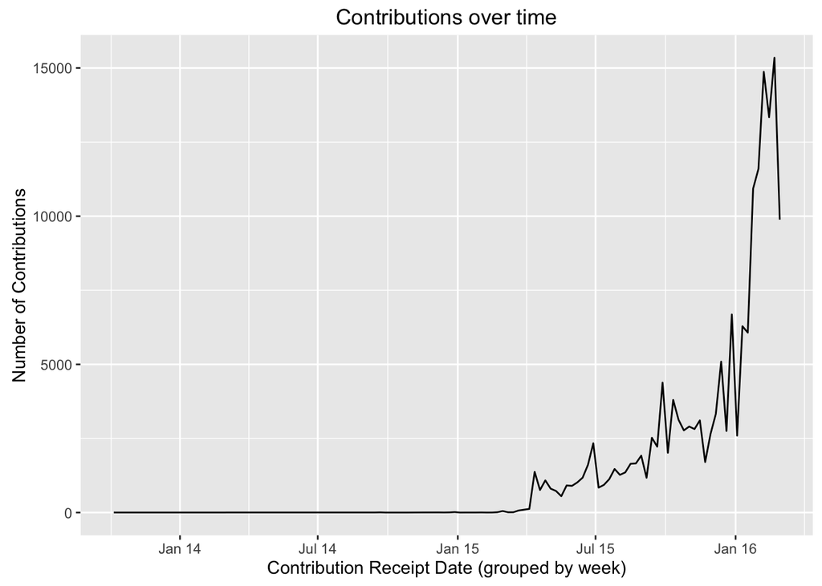

```
## [1] "Summary"
```

```
##         Min.      1st Qu.       Median         Mean      3rd Qu.
## "2013-10-11" "2015-10-19" "2016-01-13" "2015-12-08" "2016-02-11"
##         Max.
## "2016-02-29"
```

From this plot we can see that the number of contributions has increased overtime. However the data and summary show an outlier in 2013. I believe that this could be related to possible data entry errors or data recorded later than the transaction occurred.

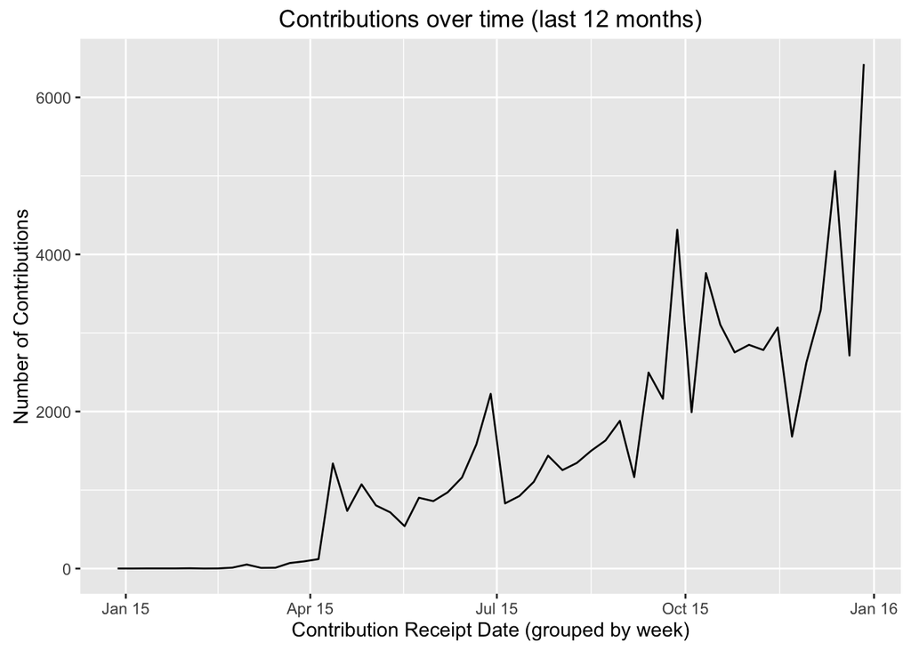

### Of the features you investigated, were there any unusual distributions? Did you perform any operations on the data to tidy, adjust, or change the form of the data? If so, why did you do this?

When performing the initial review of the data, I found that there were a couple of outliers that affected the spread of the value of the contributions of the data. These outliers included:

- A contribution of 3,686,000
- A contribution of -5,400
- Contributions recorded with dates outside of the last 12 months

## Bivariate Analysis

### Relationships between the main features

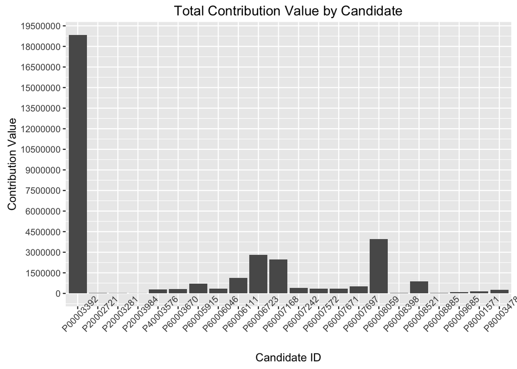

In order to see the spread of the value of the contributions I applied a SQRT coordinate transformation on the y-axis, which can be seen on the plot below.

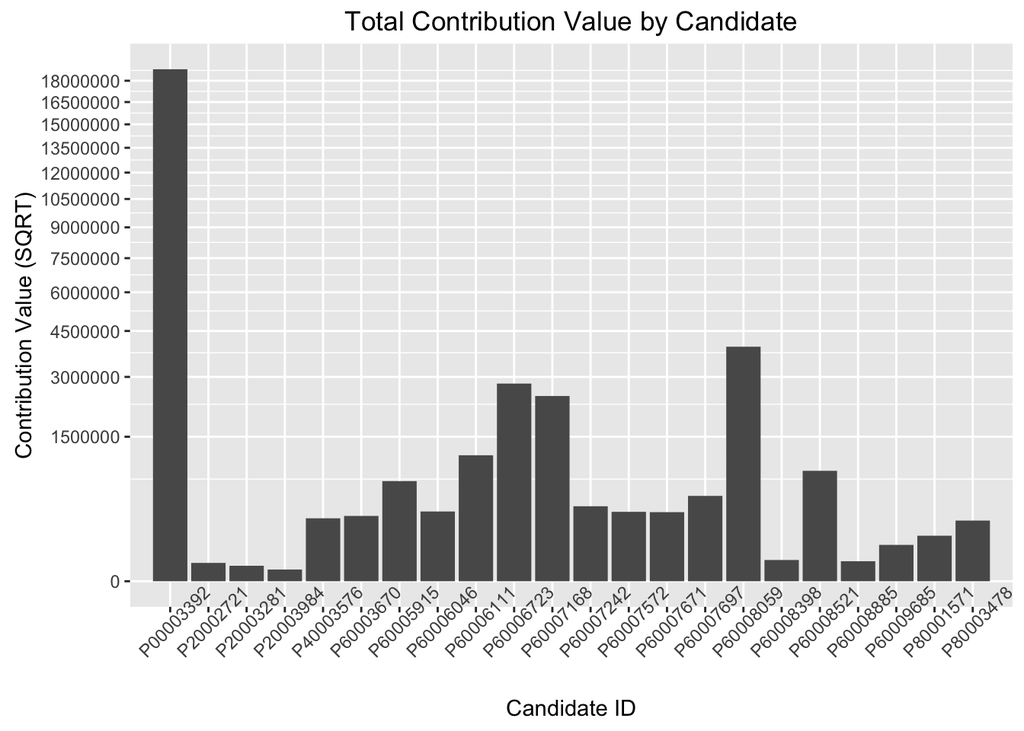

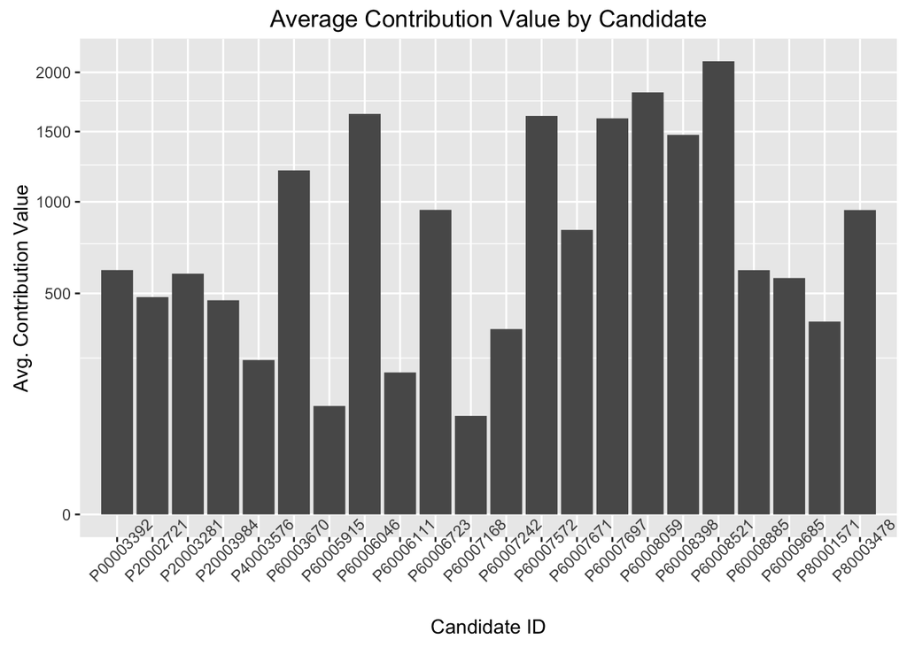

[figure not shown]

[figure not shown]

### Relationships between other features

#### Contribution Values by Employment Status

[figure not shown]

#### Contribution Values by locaiton

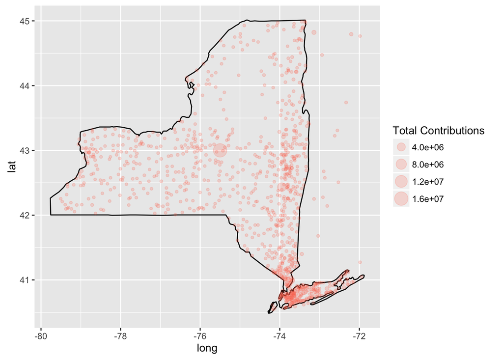

#### Contribution Values over time

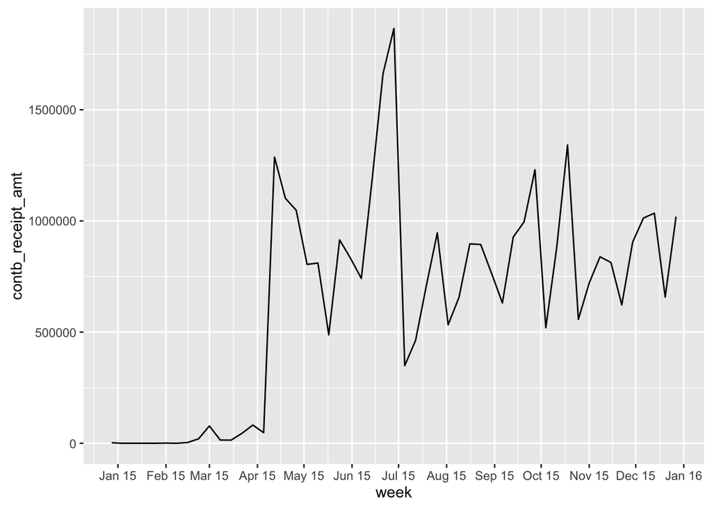

### What was the strongest relationship you found?

As the campaigning process ramps up / progresses further the number of contributions increase

## Multivariate Analysis

### Talk about some of the relationships you observed in this part of the investigation. Were there features that strengthened each other in terms of looking at your feature(s) of interest?

### Were there any interesting or surprising interactions between features?

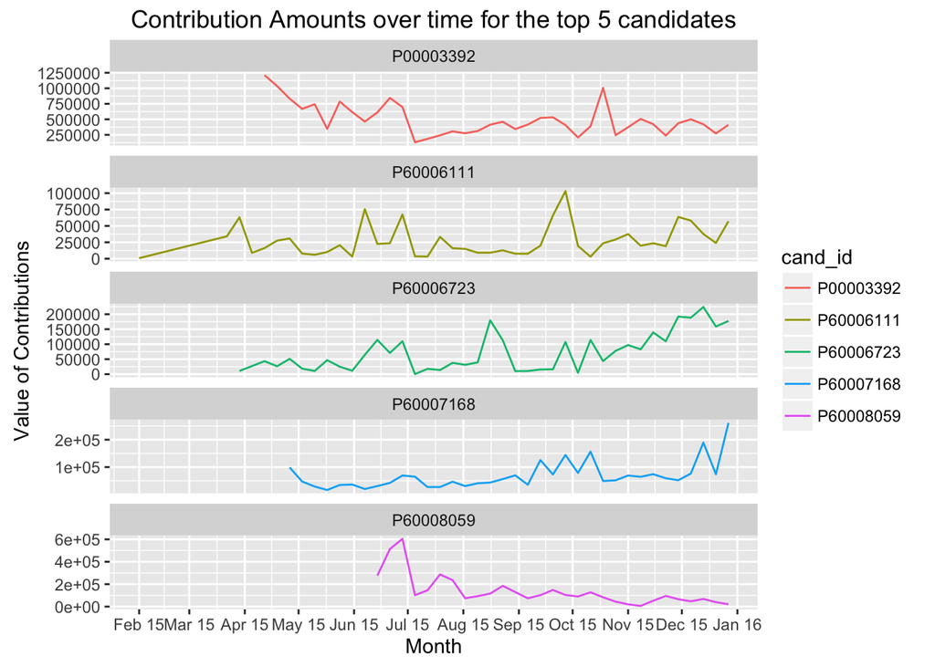

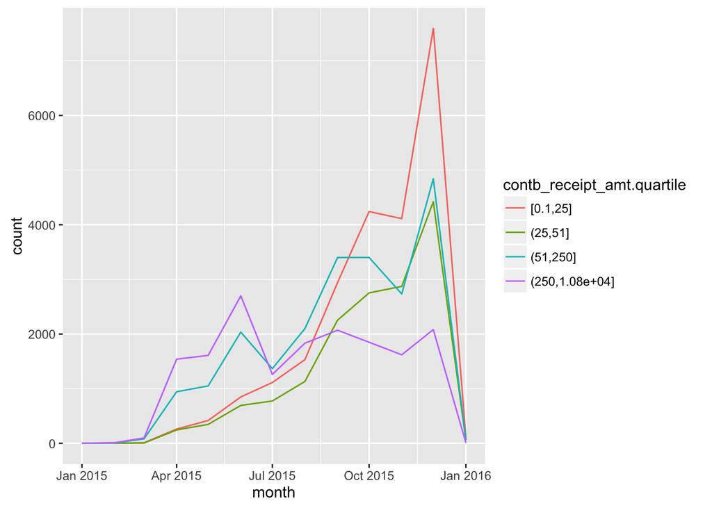

### OPTIONAL: Did you create any models with your dataset? Discuss the strengths and limitations of your model.